# Assignment01

Jacopo Lot

2023-11-02

#### Setting the working environment:

```r
rm(list=ls(all=TRUE))
setwd("C:/Users/JACOPO/Desktop/Assignment env. ec")
```

## Point 1: Derive the condition for asbsolute decoupling

#### We have absolute decoupling when GDP increases while CO2 emissions decrease. Therefore, in terms of growth rates we have that: gr(GDP)>0 while gr(CO2)<0. Moreover, since gr(CI) = gr(CO2) - gr(GDP), where CI is the Carbon Intensity of GDP CI = CO2/GDP, we have that gr(CI)<0 since gr(GDP)>0 and gr(CO2)<0. Therefore, we have that: gr(GDP)>0 and gr(CO2)<0 => gr(CI)<0. The final result is that: |gr(CI)|>|gr(GDP)|

## Point 2: Download WDI data

#### Let us download the WDI data for Poland:

```r
FE = WDI(indicator='1.1_TOTAL.FINAL.ENERGY.CONSUM', country=c('POL'), start=1990, end=2015)
GDP = WDI(indicator='NY.GDP.MKTP.PP.KD', country=c('POL'), start=1990, end=2015)
POP = WDI(indicator='SP.POP.TOTL', country=c('POL'), start=1990, end=2015)
CO2 = WDI(indicator='EN.ATM.CO2E.KT', country=c('POL'), start=1990, end=2015)
```

#### Let us fix the problem with the isocode in the energy data (FE):

```r
FE <- FE  %>%
  mutate(iso3c = iso2c) %>%
  mutate(iso2c = "PL")
```

#### Let us merge all variables in one dataframe:

```r
library(dplyr)
data <- join_all(list(CO2,FE,GDP,POP), type='left')
data <- (select(data,1, 2, 4, 6,5,7, 8))
data <- data %>% dplyr::rename_with(.cols = c(4:7), ~c("CO2", "FE", "GDP", "POP"))
```

## Point 3: Compute the Kaya components over time 1990-2015 (Poland)

#### The Kaya identity is: CO2PC = CE * EI * GDPPC, where C02PC = CO2/POP, CE = CO2/FE, EI = FE/GDP and GDPPC = GDP/POP. Moreover, we also consider the carbon intensity of GDP which is: CI = CO2/GDP.

```r
data <- data %>%
  mutate(EI = FE/GDP) %>% # [tJ/$] EI
  mutate(CE = CO2/FE) %>% # [kt/tJ] CE
  mutate(CI = CO2/GDP) %>% # [kt/$] CI
  mutate(gdppc = GDP/POP) %>% # [$/person]
  mutate(co2pc = CO2/POP) # [kt/person]
print(data[,-c(1:2)])
```

```
##    year     CO2       FE          GDP      POP           EI       CE
## 1  2015 2537766 289077.4 1.050996e+12 37986412 2.750508e-07 8.778846
## 2  2014 2509591 285730.0 1.006862e+12 38011735 2.837826e-07 8.783085
## 3  2013 2585227 298304.4 9.696571e+11 38040196 3.076391e-07 8.666407
## 4  2012 2632843 303351.4 9.614220e+11 38063164 3.155237e-07 8.679186
## 5  2011 2648205 310593.6 9.467919e+11 38063255 3.280484e-07 8.526269
## 6  2010 2717708 313739.1 9.013445e+11 38042794 3.480790e-07 8.662319
## 7  2009 2523322 297260.3 8.756474e+11 38151603 3.394749e-07 8.488594
## 8  2008 2548233 308325.3 8.515305e+11 38125759 3.620837e-07 8.264754
## 9  2007 2506839 313375.4 8.172079e+11 38120560 3.834708e-07 7.999476
## 10 2006 2499828 314093.0 7.633067e+11 38141267 4.114899e-07 7.958880
## 11 2005 2398502 301353.0 7.192109e+11 38165445 4.190050e-07 7.959110
## 12 2004 2368554 301854.0 6.948439e+11 38182222 4.344199e-07 7.846686
## 13 2003 2307370 297730.8 6.618642e+11 38204570 4.498367e-07 7.749852
## 14 2002 2243913 287320.3 6.394923e+11 38230364 4.492944e-07 7.809797
```

[output cut: 39 more lines]

#### Let us plot absolute CO2 emissions:

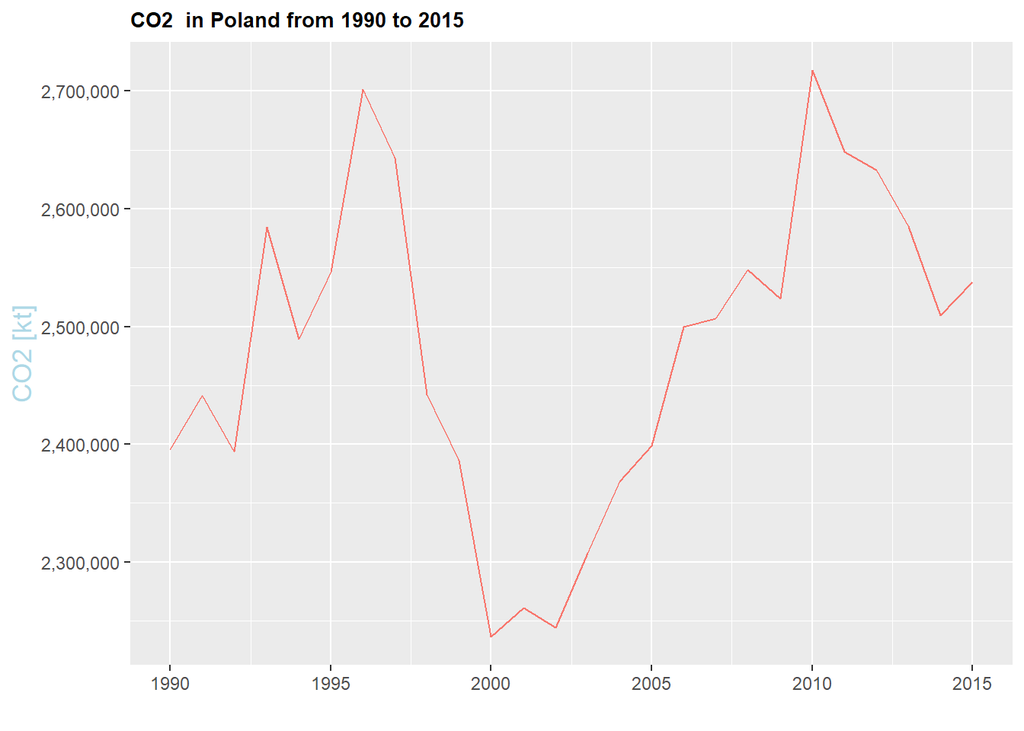

```r
library(ggplot2)
ggplot(data, aes(x = as.numeric(year))) +
  geom_line(aes(y = CO2, col = "lightblue"), show.legend = F) +
  scale_y_continuous(name = "CO2 [kt]",
  labels = scales::comma)+
  theme(
    axis.title.y = element_text(color = "lightblue", size=13),
    plot.title = element_text(size = 10, face = "bold")) +
  labs(x = "") +
  ggtitle("CO2  in Poland from 1990 to 2015")
```

#### Carbon intensity of GDP (CI):

[figure not shown]

```r
ggplot(data, aes(x = as.numeric(year))) +
  geom_line(aes(y = CI, col = "lightblue"), show.legend = F) +
  geom_line(aes(y = CO2, col = "darkred"), show.legend = F) +
  scale_y_continuous(name = "CO2 [kt]",labels = scales::comma) +
    scale_color_brewer(palette = "Set1") +
  theme(axis.title.y = element_text(color = "lightblue", size=13),
      axis.title.y.right = element_text(color = "darkred", size=13),
    plot.title = element_text(size = 10, face = "bold")) +
  labs(x = "") +
  ggtitle("CI  in Poland from 1990 to 2015")
```

#### The scatter plot of CO2 emissions per capita and GDP per capita:

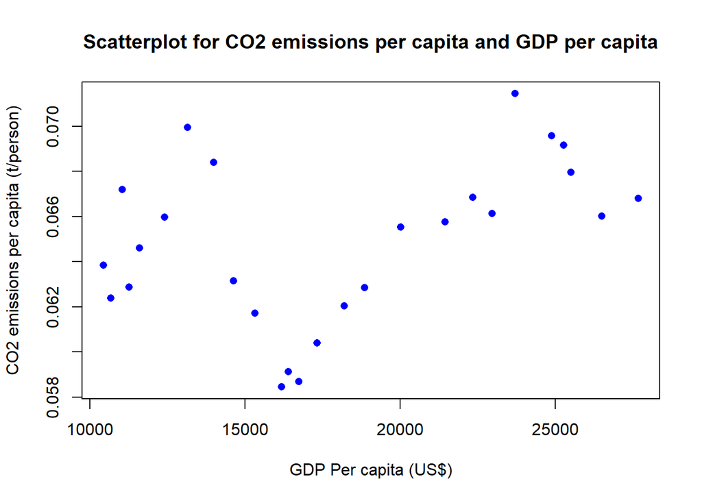

```r
plot(data$gdppc,data$co2pc, xlab="GDP Per capita (US$)",
     ylab="CO2 emissions per capita (t/person)", pch=16, col="blue")
title("Scatterplot for CO2 emissions per capita and GDP per capita")
```

## Point 4: Compute the period growth rate and the annual average grwoth rate.

#### Let us start with the period growth rates between 1990 and 2015 of all the previous variables (EI,CE,CI,GDPPC,CO2PC):

```r
growth_ovrl <- data %>%
  arrange((-year))

print(first(growth_ovrl$EI))
```

```
## [1] 2.750508e-07
```

```r
print(last(growth_ovrl$EI))
```

```
## [1] 8.161495e-07
```

```r
print(first(growth_ovrl$co2pc))
```

```
## [1] 0.06680721
```

```r
print(last(growth_ovrl$co2pc))
```

```
## [1] 0.06286642
```

```r
growth_ovrl %>%  summarise(EI = (first(EI)-last(EI))/last(EI),
            CE = (first(CE)-last(CE))/last(CE),
            CI = (first(CI)-last(CI))/last(CI),
            gdppc = (first(gdppc)-last(gdppc))/last(gdppc),
            co2pc = (first(co2pc)-last(co2pc))/last(co2pc))
```

```
##           EI        CE         CI    gdppc      co2pc
## 1 -0.6629896 0.2832317 -0.5675376 1.457289 0.06268498
```

```r
growth_ovrl <- data %>% arrange((year)) %>%  mutate(EIgr = (last(EI)-first(EI))/first(EI),
                           CEgr = (last(CE)-first(CE))/first(CE),
                           CIgr = (last(CI)-first(CI))/first(CI),
                           gdppcgr = (last(gdppc)-first(gdppc))/first(gdppc),
                           co2pcgr = (last(co2pc)-first(co2pc))/first(co2pc))
print(growth_ovrl)
```

```
##    country iso2c year     CO2       FE          GDP      POP           EI
## 1   Poland    PL 1990 2395889 350214.6 4.291060e+11 38110782 8.161495e-07
## 2   Poland    PL 1991 2441393 351624.9 3.990017e+11 38246193 8.812617e-07
## 3   Poland    PL 1992 2393783 343368.4 4.090365e+11 38363667 8.394566e-07
## 4   Poland    PL 1993 2584147 344016.4 4.243276e+11 38461408 8.107331e-07
## 5   Poland    PL 1994 2489635 339752.2 4.467864e+11 38542652 7.604354e-07
## 6   Poland    PL 1995 2546168 340003.8 4.785210e+11 38594998 7.105306e-07
## 7   Poland    PL 1996 2701396 355320.2 5.077852e+11 38624370 6.997451e-07
## 8   Poland    PL 1997 2643424 344627.0 5.405323e+11 38649660 6.375697e-07
## 9   Poland    PL 1998 2441847 318414.1 5.656157e+11 38663481 5.629513e-07
## 10  Poland    PL 1999 2386349 308978.1 5.919445e+11 38660271 5.219714e-07
## 11  Poland    PL 2000 2236322 295774.4 6.189430e+11 38258629 4.778701e-07
## 12  Poland    PL 2001 2261306 293627.4 6.267329e+11 38248076 4.685049e-07
## 13  Poland    PL 2002 2243913 287320.3 6.394923e+11 38230364 4.492944e-07
## 14  Poland    PL 2003 2307370 297730.8 6.618642e+11 38204570 4.498367e-07
```

[output cut: 66 more lines]

```r
print(lead(data$EI))
```

```
##  [1] 2.837826e-07 3.076391e-07 3.155237e-07 3.280484e-07 3.480790e-07
##  [6] 3.394749e-07 3.620837e-07 3.834708e-07 4.114899e-07 4.190050e-07
## [11] 4.344199e-07 4.498367e-07 4.492944e-07 4.685049e-07 4.778701e-07
## [16] 5.219714e-07 5.629513e-07 6.375697e-07 6.997451e-07 7.105306e-07
## [21] 7.604354e-07 8.107331e-07 8.394566e-07 8.812617e-07 8.161495e-07
## [26]           NA
```

#### Over the entire period I do not see evidence of absolute decoupling because GDPPC increases but CO2PC increases as well instead of decreasing. Moreover, the growth rate of CI (-0.57) is less than the growth rate of GDPPC (1.46), in absolute value, contradicting the condition for absolute decoupling. Regarding relative decoupling, I can see evidence of relative decoupling because the growth rate of CI is negative and the growth rate of CO2PC (0.06) is less than the growth rate of GDPPC (1.46), in absolute value. However, this reasoning will be resumed in point 5.

#### Then, the average annual growth rates are:

```r
EI_gr_a <- ((data$EI[1]/data$EI[26])^(1/26)) -1
CE_gr_a <- ((data$CE[1]/data$CE[26])^(1/26)) -1
CI_gr_a <- ((data$CI[1]/data$CI[26])^(1/26)) -1
GDPPC_gr_a <- ((data$gdppc[1]/data$gdppc[26])^(1/26)) -1
CO2PC_gr_a <- ((data$co2pc[1]/data$co2pc[26])^(1/26)) -1


growth_yoy <- data %>% arrange((-year))  %>% mutate(EI_yoy =EI/lead(EI)-1,
                                                   CE_yoy = CE/lead(CE)-1,
                                                   CI_yoy = CI/lead(CI)-1,
                                                   gdppc_yoy = (gdppc/lead(gdppc)-1),
                                                   co2pc_yoy = (co2pc/lead(co2pc)-1))

print(paste("EI_gr_a:", EI_gr_a))
```

```
## [1] "EI_gr_a: -0.0409694673385764"
```

```r
print(paste("CE_gr_a:", CE_gr_a))
```

```
## [1] "CE_gr_a: 0.00963774787442673"
```

```r
print(paste("CI_gr_a:", CI_gr_a))
```

```
## [1] "CI_gr_a: -0.0317265728609085"
```

```r
print(paste("GDPPC_gr_a:", GDPPC_gr_a))
```

```
## [1] "GDPPC_gr_a: 0.0351839882717606"
```

```r
print(paste("CO2PC_gr_a:", CO2PC_gr_a))
```

```
## [1] "CO2PC_gr_a: 0.00234114804341057"
```

#### Let us now plot the CO2 and GDP per capita growth over time:

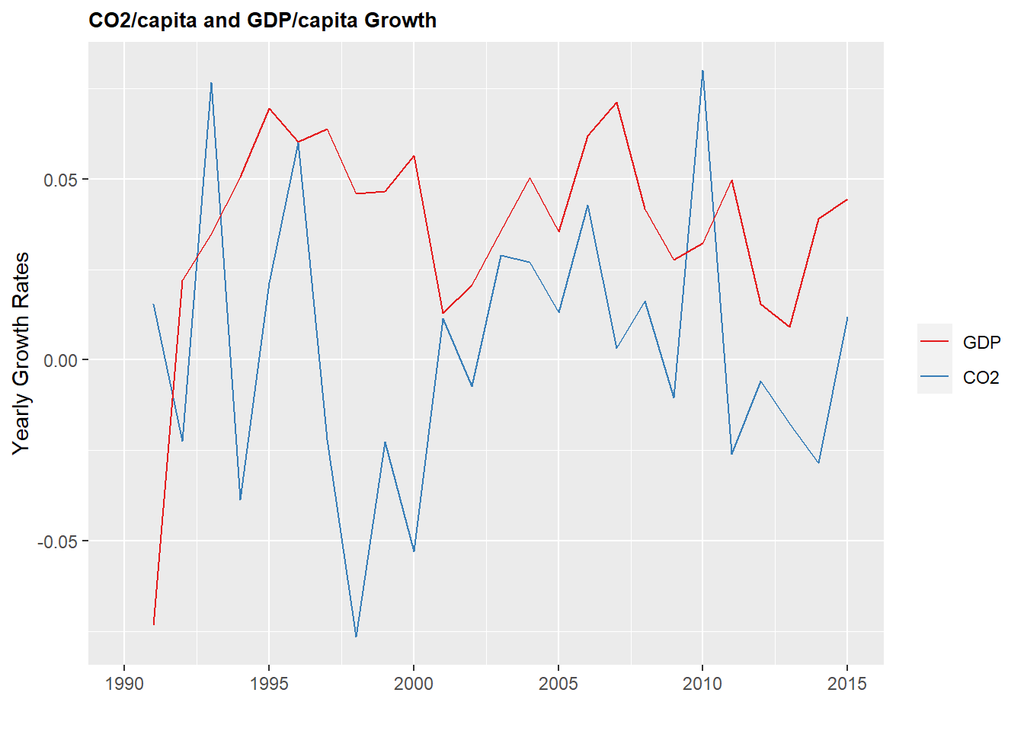

```r
growth_yoy <- growth_yoy %>%
  arrange(-year) %>%
  mutate(EI_yoy = (EI)/lead(EI)-1,
         CE_yoy = (CE)/lead(CE)-1,
         CI_yoy = (CI)/lead(CI)-1,
         gdppc_yoy = (gdppc)/lead(gdppc)-1,
         co2pc_yoy = (co2pc)/lead(co2pc)-1)


plot <- ggplot(growth_yoy, aes(x = as.numeric(year))) +
  geom_line(aes(y = co2pc_yoy, col = "lightblue")) +
  geom_line(aes(y = gdppc_yoy, col = "darkred")) +
  scale_color_brewer(palette = "Set1", labels=c('GDP', 'CO2')) +
  theme(plot.title = element_text(size = 10, face = "bold")) +
  labs(x = "", y = "Yearly Growth Rates", colour = NULL) +
  ggtitle("CO2/capita and GDP/capita Growth")
plot
```

## Point 5: Evidence of relative/absolute decoupling

#### To search for evidence of relative/absolute decoupling, I recall the previous graph of growth of GDP per capita and CO2 per capita but I add CI and then analyse the graph:

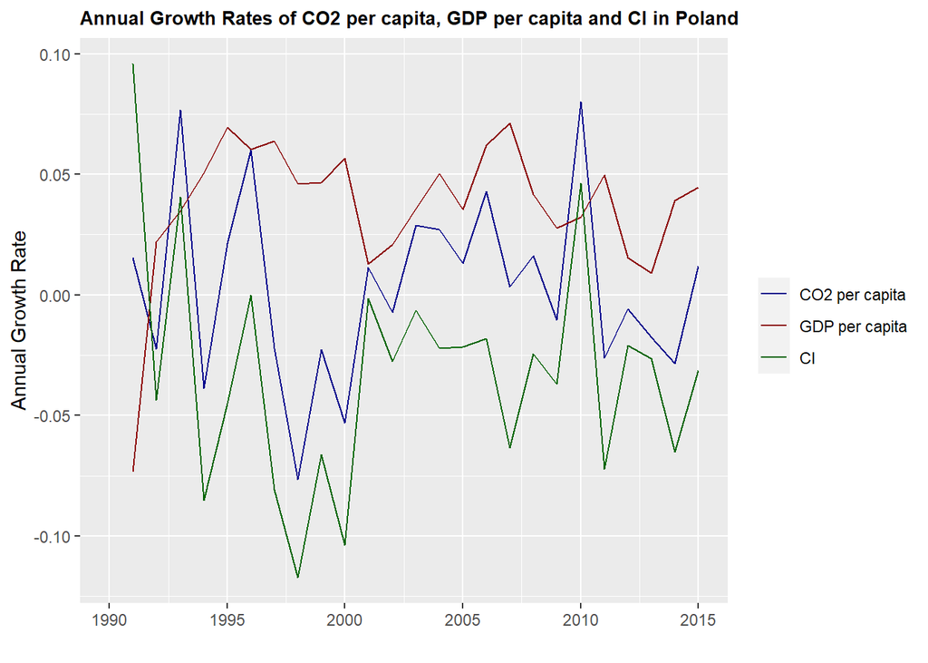

```r
growth_yoy <- growth_yoy %>%
  arrange(-year) %>%
  mutate(co2pc_yoy = (co2pc)/lead(co2pc)-1, gdppc_yoy = (gdppc)/lead(gdppc)-1, CI_yoy = (CI)/lead(CI)-1)

plot_decoupling <- ggplot(growth_yoy, aes(x = year)) +
  geom_line(aes(y = co2pc_yoy, col = "CO2 per capita")) +
  geom_line(aes(y = gdppc_yoy, col = "GDP per capita")) +
  geom_line(aes(y = CI_yoy, col = "CI")) +
  scale_color_manual(values = c("CO2 per capita" = "darkblue", "GDP per capita" = "darkred", "CI" = "darkgreen"),
                     labels = c('CO2 per capita','GDP per capita','CI')) +
  theme(plot.title = element_text(size = 10, face = "bold")) +
  labs(x = "", y = "Annual Growth Rate", colour = NULL) +
  ggtitle("Annual Growth Rates of CO2 per capita, GDP per capita and CI in Poland")

plot_decoupling
```

#### I observe relative decoupling if the dark blue line (CO2PC growth) consistently stays below the dark red line (GDPPC growth): in relative decoupling, the growth rate of CO2 per capita is less than the growth rate of GDP per capita. Moreover, the dark green line (CI growth) should be consistently below 0 (in relative decoupling we have negative growth for CI). This is the case for the majority of the time period, except from the sub-period 1990-1995 and around 2010. Therefore, there is some evidence of relative decoupling. I observe absolute decoupling if the dark blue line (CO2PC growth) consistently stays below 0 (negative growth) while the dark red line (GDPPC growth) consistently stays above 0 (positive growth): in absolute decoupling, GDP per capita increases while CO2 per capita decreases. This is not the case for CO2PC growth. Therefore, I conclude that, since there is no evidence of absolute decoupling because the CO2PC line is not consistently below zero but there is some evidence of relative decoupling , then my analysis shows some evidence of relative decoupling in Poland between 1990 and 2015, but not for the entirety of the time period.

.